# Protein Analysis

by ContextBase, http://contextbase.github.io

John Akwei, ECMp ERMp Data Scientist

February 6, 2016

# Synopsis

This document is comprised of the following R data analysis items:

The dataset examined is: data_protein.csv

The following parameters of data_protein.csv are examined: 1) a - g are the protein signal values (they are not absolute values), but they are relative for each protein separately. They represent the total amount of protein in that sample.

2. V are the variables measured from each of the 61 samples. v8 - v11 weren’t done by me and represent fold changes compared to some control.
3. V3 is known to be “bad or hi” above 0.7 and is the most important followed by v2 = “bad or hi” at 7 or 8 and above, and then v1 which is considered to be “normal” between 0.86 and 1.76 ug/ml. v3 is the ratio of v2/k (potassium).
4. Previous tried: Fisher’s exact tests by cross tabulation using hi (0.7) v3 group that contained either hi or lo protein vs the rest of the v3 group < 0.7. Samples hi in v3 are more likely than lo to have hi/lo levels of protein c.

Data Science Goals:  
1. To know if my biomarkers (western blot data/signal intensity) can be used to predict elevated levels of some variable.

2. To find cutoff points for these markers that could indicate “good” or “bad” (using a certain amount of signal measured).
3. Find any meaningful correlations with the proteins of interest (POI), n = 7 columns, that could help predict biological dysfunction.
4. Develop a methodical approach to analyzing the data so I can answer those 2 questions.

#### Processing Requirements

```r
setwd("C:/Users/johnakwei/Dropbox/Programming/Morphotypes")
if (!require("ggplot2")) {install.packages("ggplot2"); require("ggplot2")}
```

# Data Input

```r
data_protein <- read.csv("data_protein.csv", header=T, na.strings="NA")
```

# Graphs

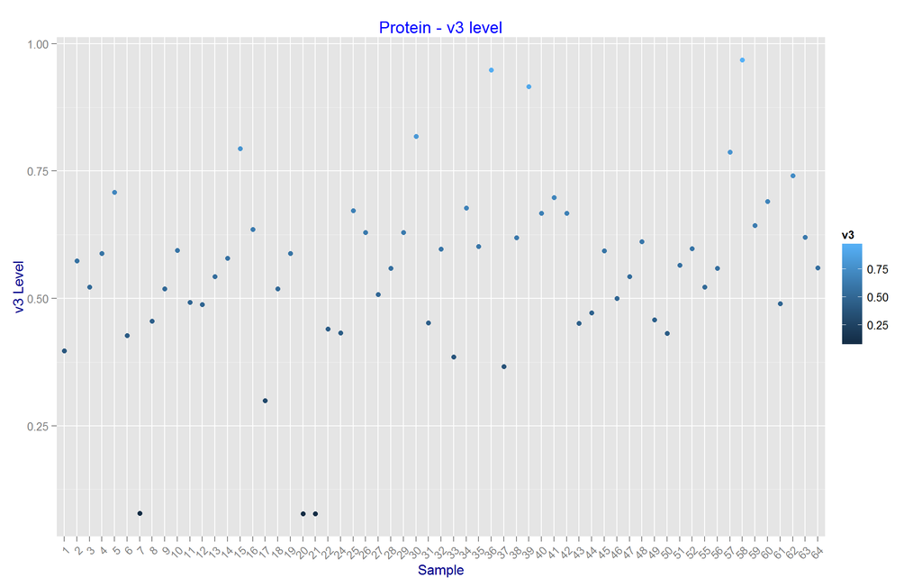

```r
ggplot(data_protein, aes(x=as.factor(data_protein$sample),
                         y=data_protein$v3)) +
geom_point(aes(col=data_protein$v3)) + ggtitle("Protein - v3 level") +
xlab("Sample") + ylab("v3 Level") +
theme(plot.title=element_text(color="blue")) +
theme(axis.title=element_text(color="darkblue")) +
theme(axis.text.x=element_text(angle=45, hjust=1)) +
labs(col="v3")
```

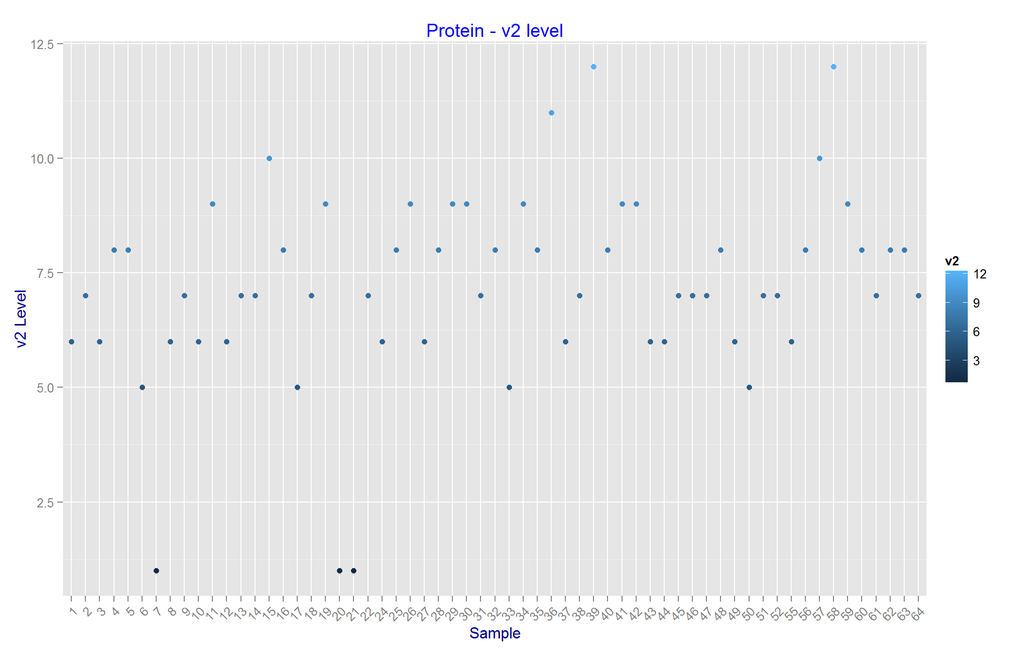

```r
ggplot(data_protein, aes(x=as.factor(data_protein$sample),
                         y=data_protein$v2)) +
geom_point(aes(col=data_protein$v2)) + ggtitle("Protein - v2 level") +
xlab("Sample") + ylab("v2 Level") +
theme(plot.title=element_text(color="blue")) +
theme(axis.title=element_text(color="darkblue")) +
theme(axis.text.x=element_text(angle=45, hjust=1)) +
labs(col="v2")
```

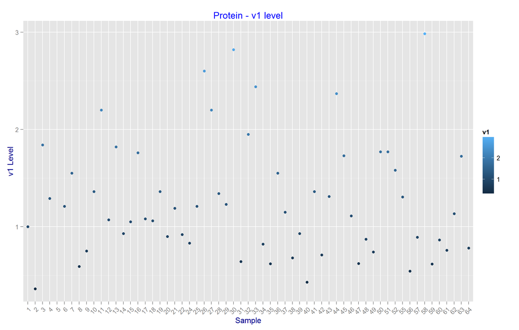

```r
ggplot(data_protein, aes(x=as.factor(data_protein$sample),
                         y=data_protein$v1)) +
geom_point(aes(col=data_protein$v1)) + ggtitle("Protein - v1 level") +
xlab("Sample") + ylab("v1 Level") +
theme(plot.title=element_text(color="blue")) +
theme(axis.title=element_text(color="darkblue")) +
theme(axis.text.x=element_text(angle=45, hjust=1)) +
labs(col="v1")
```

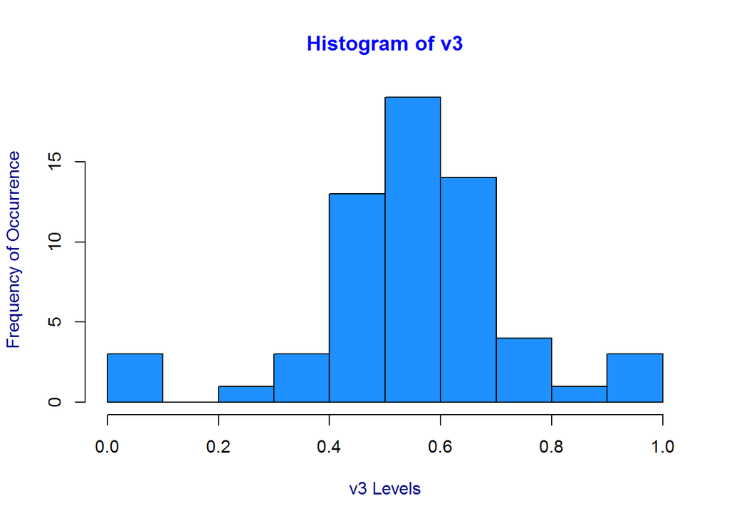

```r
hist(data_protein$v3, main="Histogram of v3", col.main="blue",
     xlab="v3 Levels", ylab="Frequency of Occurrence",
     col.lab="darkblue", col="Dodger Blue")
```

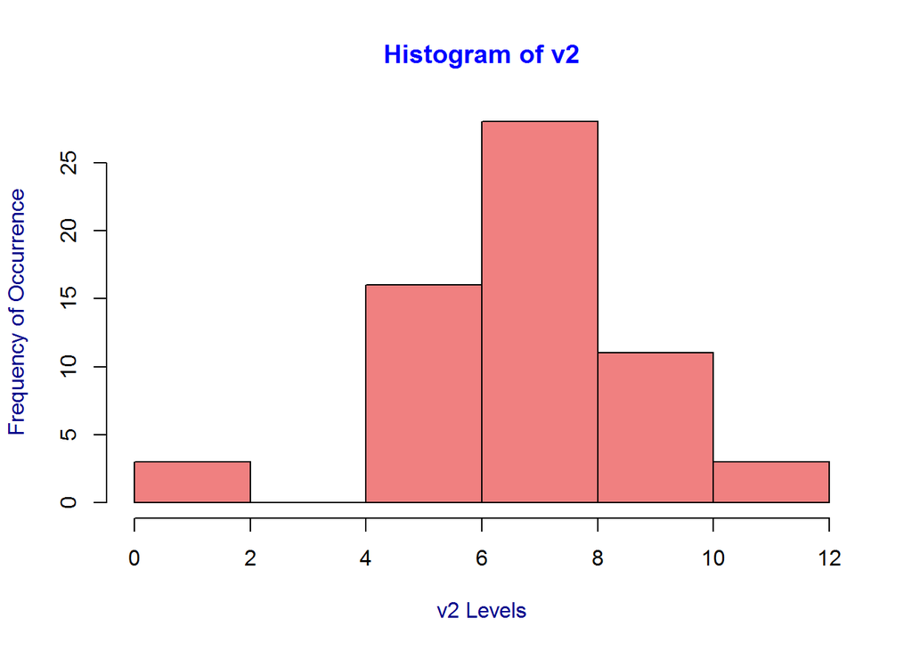

```r
hist(data_protein$v2, main="Histogram of v2", col.main="blue",
     xlab="v2 Levels", ylab="Frequency of Occurrence",
     col.lab="darkblue", col="Light Coral")
```

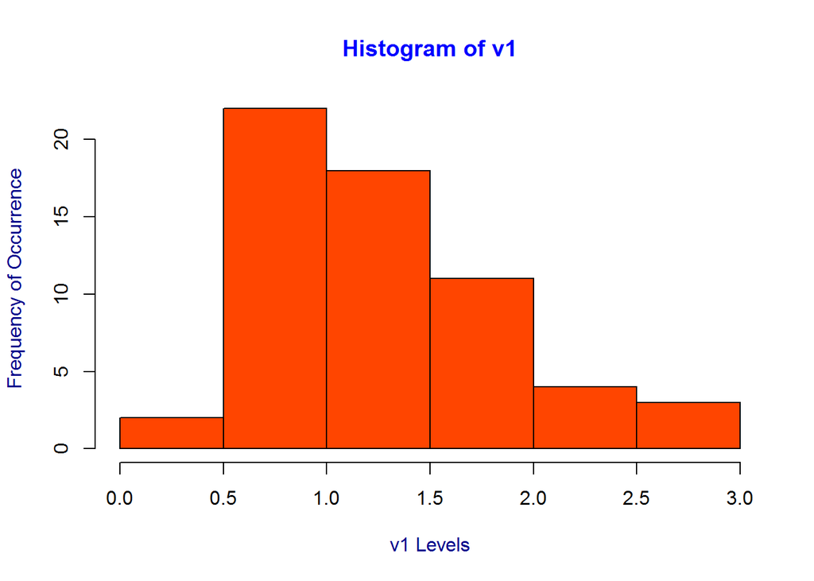

```r
hist(data_protein$v1, main="Histogram of v1", col.main="blue",
     xlab="v1 Levels", ylab="Frequency of Occurrence",
     col.lab="darkblue", col="Orange Red")
```

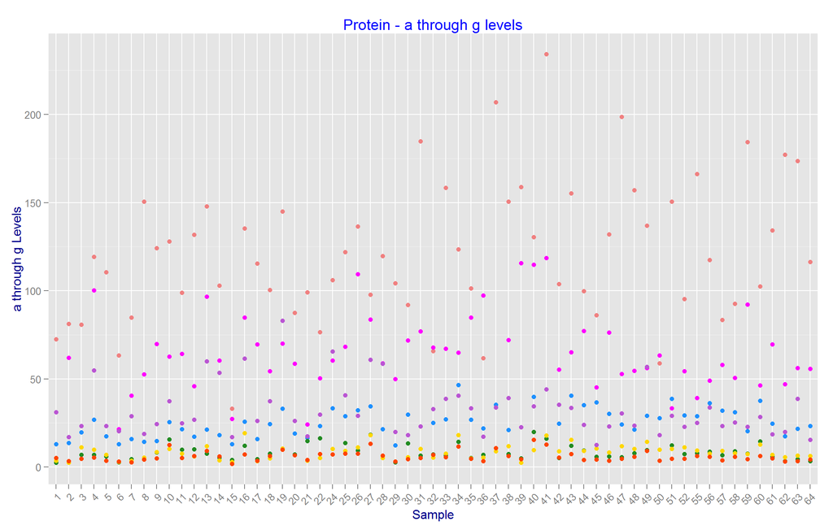

```r
ggplot(data_protein) +
geom_point(aes(x=as.factor(data_protein$sample), y=data_protein$a),
           col="Dodger Blue") +
geom_point(aes(x=as.factor(data_protein$sample), y=data_protein$b),
           col="Forest Green") +
geom_point(aes(x=as.factor(data_protein$sample), y=data_protein$c),
           col="Gold") +
geom_point(aes(x=as.factor(data_protein$sample), y=data_protein$d),
           col="Light Coral") +
geom_point(aes(x=as.factor(data_protein$sample), y=data_protein$e),
           col="Orange Red") +
geom_point(aes(x=as.factor(data_protein$sample), y=data_protein$f),
           col="Magenta") +
geom_point(aes(x=as.factor(data_protein$sample), y=data_protein$g),
           col="Medium Orchid") +
ggtitle("Protein - a through g levels") +
xlab("Sample") + ylab("a through g Levels") +
theme(plot.title=element_text(color="blue")) +
theme(axis.title=element_text(color="darkblue")) +
theme(axis.text.x=element_text(angle=45, hjust=1))
```

# Linear Regression

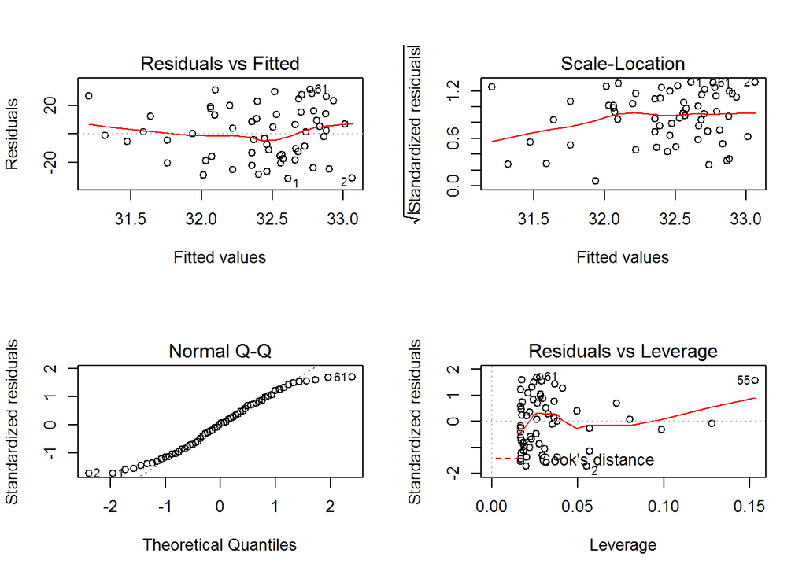

```r
fit <- lm(data_protein$sample~data_protein$v1)
layout(matrix(c(1,2,3,4),2,2))
plot(fit)
```

```r
layout(matrix(1,1,1))
```

# Correlation

```r
cor.test(data_protein$a, data_protein$v1, method="spearman")
```

```
##
##  Spearman's rank correlation rho
##
## data:  data_protein$a and data_protein$v1
## S = 27620, p-value = 0.1433
## alternative hypothesis: true rho is not equal to 0
## sample estimates:
##       rho
## 0.1928574
```

# T-Test

```r
t.test(data_protein$a, data_protein$v1)
```

```
##
##  Welch Two Sample t-test
##
## data:  data_protein$a and data_protein$v1
## t = 23.042, df = 59.665, p-value < 2.2e-16
## alternative hypothesis: true difference in means is not equal to 0
## 95 percent confidence interval:
##  21.92272 26.09134
## sample estimates:
## mean of x mean of y
## 25.278116  1.271083
```